# Fundamentos de Data Science: PEC1 - Text Mining

Enrique Rocho Simon

Noviembre del 2022

# 1 Introducción

## 1.1 Descripción de la PEC a realizar

La prueba está estructurada en 8 ejercicios teórico-prácticos que piden que se desarrolle la fase de preparación y estimación de un modelo utilizando un juego de datos.

Deben responderse al menos 7 de los 8 ejercicios para poder superar la PEC. Para optar a la máxima nota tienen que responderse los 8 ejercicios.

## 1.2 Criterios de evaluación

**Ejercicios teóricos**  
Todos los ejercicios deben ser presentados de forma razonada y clara. No se aceptará ninguna respuesta que no esté claramente justificada.

**Ejercicios prácticos**  
Para todas las PEC es necesario documentar en cada ejercicio práctico qué se ha hecho y cómo se ha hecho.

| Pregunta | Criterio de valoración | Peso |
| --- | --- | --- |
| 1 | Respuesta a la pregunta de forma correcta | 5% |
| 2 | Primera visualización | 5% |
| 2 | Segunda visualización | 5% |
| 3 | Se realiza el gráfico solicitado | 10% |
| 3 | Se contestan las cuestiones y se justifican | 5% |
| 4 | Se describen los resultados que se solicitan | 15% |
| 5 | Se contesta a la pregunta planteada | 10% |
| 6 | Se entrena el modelo solicitado | 15% |
| 6 | Se describe el proceso solicitado | 10% |
| 7 | Se contesta a la cuestión planteada | 10% |
| 8 | Se contesta a la cuestión planteada | 10% |

## 1.3 Formato y fecha de entega

El formato de entrega es: studentname-PECn.html  
Fecha de Entrega: 27/11/2022  
Se debe entregar la PEC en el buzón de entregas del aula

# 2 Base teórica

Esta práctica se basa en una de las aplicaciones de la **Minería de Textos**, que consiste en clasificar documentos en función de su temática. Esto es lo que se conoce como **Topic Model**. Para realizar la clasificación utilizaremos el algoritmo de aprendizaje automático K-Nearest Neighbors (K-NN).

Por Topic Model entendemos procesos de aprendizaje automático que tienen por objetivo descubrir el tema subyacente en una colección de documentos. Generalizando un poco más, Topic Model busca patrones en el contenido de los documentos y lo hace en base a la frecuencia de aparición de palabras.

El análisis que realizamos se basa en el hecho de que en documentos pertenecientes a un mismo tema aparecerán palabras que se repetirán con mayor frecuencia. Por lo tanto, el análisis plantea la clasificación de documentos utilizando como criterio las palabras que son más frecuentes en cada temática. Estas frecuencias se almacenarán en una matriz de datos, donde las variables serán las palabras y los registros los documentos, que será la base para que puedan trabajar los algoritmos de aprendizaje automático, que en esta práctica se centran en el K-NN.

En este ámbito de conocimiento se basan los sistemas de clasificación documental, búsqueda de contenidos y sistemas de recomendación entre otros.

## 2.1 Competencias

Las competencias que se trabajan en esta práctica son:

- Capacidad de analizar datos textuales en R.
- Capacidad de implementar el algoritmo K-NN para la clasificación de textos según temática.

## 2.2 Objetivos

- Asimilar correctamente los apartados 1.2.1, 1.2.2, 2.1, 3.2.1 y 3.2.2.

## 2.3 Recursos

Para realizar esta práctica recomendamos la lectura de lo siguiente:

- Apartados 1.2.1, 1.2.2, 2.1, 3.2.1 y 3.2.2 del material didático **Análisis de datos para organizaciones**.
- Los siguientes **Recursos en la web:**

  – [Journal Digital: Topic Modeling](http://journalofdigitalhumanities.org/2-1/topic-modeling-a-basic-introduction-by-megan-r-brett/)  
  – [Wikipedia: Topic Modeling](http://en.wikipedia.org/wiki/Topic_model)  
  – [Wikipedia: Sistemas de recomendación](http://es.wikipedia.org/wiki/Sistema_de_recomendaci%C3%B3n)  
  – [CRAN: Text Mining Package](http://cran.r-project.org/web/packages/tm/tm.pdf)

## 2.4 Nota: Propiedad intelectual

> A menudo es inevitable, al producir una obra multimedia, hacer uso de recursos creados por terceras personas. Es por lo tanto comprensible hacerlo en el marco de una práctica de los estudios de Informática, Multimedia y Telecomunicación de la UOC, siempre y cuando esto se documente claramente y no suponga plagio en la práctica.

> Por lo tanto, al presentar una práctica que haga uso de recursos ajenos, se debe presentar junto con ella un documento en el que se detallan todos ellos, especificando el nombre de cada recurso, su autor, el lugar dónde se obtuvo y su estatus legal: si la obra está protegida por el copyright o se acoge a alguna otra licencia de uso (Creative Commons, licencia GNU, GPL …). El estudiante deberá asegurarse de que la licencia no impide específicamente su uso en el marco de la práctica. En caso de no encontrar la información correspondiente tendrá que asumir que la obra está protegida por copyright.

> Deberéis, además, adjuntar los ficheros originales cuando las obras utilizadas sean digitales, y su código fuente si corresponde.

# 3 Enunciado

El objetivo es clasificar un conjunto de artículos de Reuters correspondientes a distintas temáticas: acquire, crude, earn, grain, interest, money-fx, ship y trade. Se trata de temáticas relacionadas con inversiones financieras y fondos de inversión.

Se utiliza un sistema de clasificación de documentos que se basa en el algoritmo de aprendizaje automático K-NN (K-Nearest Neighbors o K vecinos más próximos).

Los datos están en el fichero data_reuter.txt. Este fichero contiene dos campos, el primero se corresponde con el tipo de temática (en total hay 8) y el segundo campo contiene el artículo relacionado. Entre las 8 temáticas se seleccionan 2 para realizar el análisis.

Para mostrar el funcionamiento del algoritmo de clasificación se utiliza un 70% de los artículos para entrenar el modelo de aprendizaje. Dicho algoritmo se aplica sobre el 30% de artículos restantes con el objetivo de predecir su temática.

# 4 Apartados de la práctica

El código R que utilizaremos en la práctica se divide en apartados según las tareas que iremos realizando:

- Lectura y selección de los datos
- Creación del corpus, limpieza y acondicionado del texto
- Generación de la Matriz de Términos (TDM-Terms Data Matrix).
- Creación de la TDM.
  - Subselecciones sobre TDM.
- Descripción de la TDM.
- Creación de un data.frame apto para K-NN.
- Construcción del Modelo de Clasificación con la función `knn()` del paquete “class” y con la función `train()` del paquete “caret”.
- Validación del Modelo de Clasificación.

# 5 Inicialización de variables

Instalamos los packages de R que necesitaremos para realizar la práctica:

- install.packages(“tm”)
- install.packages(“plyr”)
- install.packages(“class”)
- install.packages(“ggplot2”)
- install.packages(“SnowballC”)
- install.packages(“wordcloud”)
- install.packages(“Rcpp”)
- install.packages(“caret”)

Definimos el directorio de trabajo donde tendremos guardado el fichero de datos.

- setwd(“ruta”)

Para instalar los paquetes y definir el directorio de trabajo podéis eliminar los asteriscos delante de los **install.packages()** y **setwd()** seleccionarlos y ejecutarlos como comandos de R (Control+Intro).

```r
## Cargamos los paquetes necesarios para ejecutar las funciones que se describen a continuación:
# Para la función Corpus()
library(tm)
# Para la función rbind.fill
library(plyr)
# Para la función knn()
library(class)

# En R una variable tipo factor es una variable categórica que puede contener tanto números como carácteres. Se trata de un tipo de variable muy útil para realizar tareas de modelización estadística.

# En R, por defecto, las columnas con carácteres no numéricos son tratadas como factores. Para evitarlo y garantizar que estas columnas sigan siendo consideradas carácteres, fijaremos el siguiente parámetro
options(stringsAsFactors = FALSE)

# Leemos los datos
data <- read.table('E:/Análisis de datos/Fundamentos Data Science/PEC1/data_reuter.txt', header=FALSE, sep='\t')
# Describimos los datos
## Cuantos hay en total
nrow(data)
```

```
## [1] 5485
```

```r
# Cuantos hay para cada tipo de temática
table(data$V1)
```

```
##
##      acq    crude     earn    grain interest money-fx     ship    trade
##     1596      253     2840       41      190      206      108      251
```

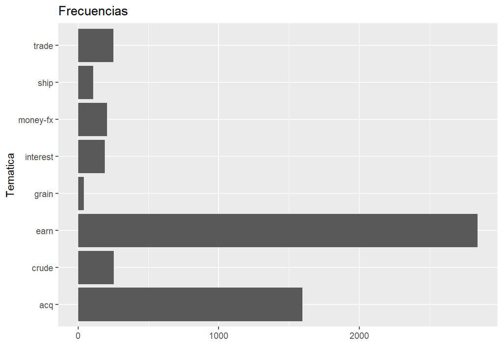

```r
library(ggplot2)
qplot(data$V1,xlab="Tematica", main = "Frecuencias")+ coord_flip()
```

```r
# Finalmente seleccionamos dos temáticas: acq y earn
data2<-data[which(data$V1 %in% c("acq","earn")),]
## Cuantos hay en total
nrow(data2)
```

```
## [1] 4436
```

# 6 Creación del corpus, limpieza y acondicionado del texto.

A continuación creamos un corpus para cada temática sobre los que se realizarán las siguietes tareas de **acondicionado de texto**:

1. Eliminar signos de puntuación.
2. Eliminar espacios en blanco innecesarios.
3. Convertir todo el texto a minúsculas.
4. Eliminar palabras sin significado propio.
5. Eliminar números.
6. Substituir las palabras derivadas por su palabra raíz.

```r
# Creación del corpus de la temática acq
## Seleccionamos la temática
data_acq<-data2[(data2$V1=="acq"),]
## Construimos el corpus
source <- VectorSource(data_acq$V2)
corpus1 <- Corpus(source)
## Acondicionamos el corpus
### Convertir todo el texto a minúsculas
corpus1 <- tm_map(corpus1, content_transformer(tolower))
### Elimina números
corpus1 <- tm_map(corpus1, removeNumbers)
### Eliminar signos de puntuación
corpus1 <- tm_map(corpus1, removePunctuation)
###Eliminar espacios en blanco innecesarios
corpus1 <- tm_map(corpus1, stripWhitespace)
### Eliminar palabras sin significado propio
v_stopwords <- c(stopwords("english"),c("dont","didnt","arent","cant","one","also","said"))
corpus1 <- tm_map(corpus1, removeWords, v_stopwords)
### Eliminar signos de puntuación
corpus1 <- tm_map(corpus1, removePunctuation)
### Substituir las palabras derivadas por su palabra raíz
corpus1 <- tm_map(corpus1, stemDocument, language="english")

# Creación del corpus de la temática earn
## Seleccionamos la temática
data_earn<-data2[(data2$V1=="earn"),]
## Construimos el corpus
source <- VectorSource(data_earn$V2)
corpus2 <- Corpus(source)
## Acondicionamos el corpus
corpus2 <- tm_map(corpus2, content_transformer(tolower))
corpus2 <- tm_map(corpus2, removeNumbers)
corpus2 <- tm_map(corpus2, removePunctuation)
corpus2 <- tm_map(corpus2, stripWhitespace)
v_stopwords <- c(stopwords("english"),c("dont","didnt","arent","cant","one","also","said"))
corpus2 <- tm_map(corpus2, removeWords, v_stopwords)
corpus2 <- tm_map(corpus2, removePunctuation)
corpus2 <- tm_map(corpus2, stemDocument, language="english")
```

# 7 Generación de la Matriz de Términos (TDM-Terms Data Matrix)

Seguidamente construimos una matriz de términos para cada temática para posteriormete unirlas en una misma lista.

```r
# Construimos la matrix de documentos de la temática acq
mat_acq <- TermDocumentMatrix(corpus1)
## Controlamos la dispersión (Sparsity): Número de celdas igual a cero respecto al total.
mat_acq<- removeSparseTerms(mat_acq,  0.80)
inspect(mat_acq)
```

```
## <<TermDocumentMatrix (terms: 20, documents: 1596)>>
## Non-/sparse entries: 11747/20173
## Sparsity           : 63%
## Maximal term length: 9
## Weighting          : term frequency (tf)
## Sample             :
##          Docs
## Terms     1060 1347 1446 181 28 49 557 68 771 797
##   compani    7    9    6   1  7  6   5  7   8  12
##   corp       1    6    3   3  1  0   3  1   1   6
##   dlrs       9   10    7   4 11 17  19 15   9   4
##   inc        3    2    1   3  3  5   1  4   4   2
##   mln        4    6    9   1  5  7  19  4   3   5
##   offer      8    7   14  16  5 11   1  7   7   0
##   pct        2    1    3   5  2  2   2  6   1   3
##   reuter     1    1    1   1  1  1   2  1   1   2
##   share     14   12    5   6  6  7   5 11   7   1
##   will       1    4    3   1  9  0   2  0   3   3
```

```r
mat_acq<-list(name="acq",mat=mat_acq)
mat_acq
```

```
## $name
## [1] "acq"
##
## $mat
## <<TermDocumentMatrix (terms: 20, documents: 1596)>>
## Non-/sparse entries: 11747/20173
## Sparsity           : 63%
## Maximal term length: 9
## Weighting          : term frequency (tf)
```

```r
str(mat_acq)
```

```
## List of 2
##  $ name: chr "acq"
##  $ mat :List of 6
##   ..$ i       : int [1:11747] 1 2 3 4 5 6 7 8 9 10 ...
##   ..$ j       : int [1:11747] 1 1 1 1 1 1 1 1 1 1 ...
##   ..$ v       : num [1:11747] 1 1 3 4 4 2 1 2 1 2 ...
##   ..$ nrow    : int 20
##   ..$ ncol    : int 1596
##   ..$ dimnames:List of 2
##   .. ..$ Terms: chr [1:20] "acquir" "buy" "common" "compani" ...
##   .. ..$ Docs : chr [1:1596] "1" "2" "3" "4" ...
##   ..- attr(*, "class")= chr [1:2] "TermDocumentMatrix" "simple_triplet_matrix"
##   ..- attr(*, "weighting")= chr [1:2] "term frequency" "tf"
```

```r
# Construimos la matrix de documentos de la temática earn
mat_earn <- TermDocumentMatrix(corpus2)
mat_earn<- removeSparseTerms(mat_earn,  0.80)
inspect(mat_earn)
```

```
## <<TermDocumentMatrix (terms: 22, documents: 2840)>>
## Non-/sparse entries: 24479/38001
## Sparsity           : 61%
## Maximal term length: 8
## Weighting          : term frequency (tf)
## Sample             :
##         Docs
## Terms    1076 1417 1537 1987 209 316 425 465 523 703
##   cts       4    5    5    4  11   3   6  14   0  12
##   dlrs     17    8   19   13  12  19  10  32  47  12
##   loss      6    5    6    8   8   2  10   5   8   8
##   mln       9   13   20   16  10  18  18  11  45   4
##   net       9    3    3    6   5   2   2   9   2   3
##   profit    8    4    6    5   5   4   1   0   6   4
##   reuter    1    1    1    1   1   1   1   1   1   1
##   share     1    4    6    7   9   2   5   7   2  10
##   shr       2    2    2    2   2   0   3   3   0   2
##   year      2    5    6    6   3   4   3  10  13   4
```

```r
mat_earn<-list(name="earn",mat=mat_earn)
mat_earn
```

```
## $name
## [1] "earn"
##
## $mat
## <<TermDocumentMatrix (terms: 22, documents: 2840)>>
## Non-/sparse entries: 24479/38001
## Sparsity           : 61%
## Maximal term length: 8
## Weighting          : term frequency (tf)
```

```r
str(mat_earn)
```

```
## List of 2
##  $ name: chr "earn"
##  $ mat :List of 6
##   ..$ i       : int [1:24479] 1 2 3 4 5 6 7 8 9 3 ...
##   ..$ j       : int [1:24479] 1 1 1 1 1 1 1 2 2 2 ...
##   ..$ v       : num [1:24479] 2 1 1 2 1 1 2 2 2 1 ...
##   ..$ nrow    : int 22
##   ..$ ncol    : int 2840
##   ..$ dimnames:List of 2
##   .. ..$ Terms: chr [1:22] "april" "compani" "inc" "mln" ...
##   .. ..$ Docs : chr [1:2840] "1" "2" "3" "4" ...
##   ..- attr(*, "class")= chr [1:2] "TermDocumentMatrix" "simple_triplet_matrix"
##   ..- attr(*, "weighting")= chr [1:2] "term frequency" "tf"
```

```r
# Juntamos ambas matrices de términos en una misma lista
mat<-list(mat_acq, mat_earn)
str(mat)
```

```
## List of 2
##  $ :List of 2
##   ..$ name: chr "acq"
##   ..$ mat :List of 6
##   .. ..$ i       : int [1:11747] 1 2 3 4 5 6 7 8 9 10 ...
##   .. ..$ j       : int [1:11747] 1 1 1 1 1 1 1 1 1 1 ...
##   .. ..$ v       : num [1:11747] 1 1 3 4 4 2 1 2 1 2 ...
##   .. ..$ nrow    : int 20
##   .. ..$ ncol    : int 1596
##   .. ..$ dimnames:List of 2
##   .. .. ..$ Terms: chr [1:20] "acquir" "buy" "common" "compani" ...
##   .. .. ..$ Docs : chr [1:1596] "1" "2" "3" "4" ...
##   .. ..- attr(*, "class")= chr [1:2] "TermDocumentMatrix" "simple_triplet_matrix"
##   .. ..- attr(*, "weighting")= chr [1:2] "term frequency" "tf"
##  $ :List of 2
##   ..$ name: chr "earn"
##   ..$ mat :List of 6
##   .. ..$ i       : int [1:24479] 1 2 3 4 5 6 7 8 9 3 ...
##   .. ..$ j       : int [1:24479] 1 1 1 1 1 1 1 2 2 2 ...
##   .. ..$ v       : num [1:24479] 2 1 1 2 1 1 2 2 2 1 ...
##   .. ..$ nrow    : int 22
##   .. ..$ ncol    : int 2840
##   .. ..$ dimnames:List of 2
##   .. .. ..$ Terms: chr [1:22] "april" "compani" "inc" "mln" ...
##   .. .. ..$ Docs : chr [1:2840] "1" "2" "3" "4" ...
##   .. ..- attr(*, "class")= chr [1:2] "TermDocumentMatrix" "simple_triplet_matrix"
##   .. ..- attr(*, "weighting")= chr [1:2] "term frequency" "tf"
```

## 7.1 Visualizaciones sobre la matriz de palabras TDM

Con las dos matrices de frecuencias `mat[[1]]$mat` para acq y `mat[[2]]$mat` para earn, podemos realizar algunas visualizaciones básicas.

```r
# Frecuencia de los 10 primeros términos en los 10 primeros documentos para ambos temas
inspect(mat[[1]]$mat[1:10,1:10])
```

```
## <<TermDocumentMatrix (terms: 10, documents: 10)>>
## Non-/sparse entries: 58/42
## Sparsity           : 42%
## Maximal term length: 7
## Weighting          : term frequency (tf)
## Sample             :
##          Docs
## Terms     1 10 2 3 4 5 6 7 8 9
##   acquir  1  1 1 1 0 0 0 0 0 0
##   buy     1  1 0 1 0 0 0 0 0 1
##   common  3  0 0 0 2 0 2 0 0 1
##   compani 4  1 9 1 0 5 1 0 1 0
##   dlrs    4  1 4 0 1 2 1 0 1 1
##   inc     2  2 3 3 0 1 0 0 1 0
##   mln     1  1 3 0 1 3 1 0 1 0
##   pct     2  1 0 0 2 2 3 0 0 2
##   reuter  1  1 1 1 1 1 1 1 1 1
##   sale    2  0 0 0 0 0 0 0 1 0
```

```r
inspect(mat[[2]]$mat[1:10,1:10])
```

```
## <<TermDocumentMatrix (terms: 10, documents: 10)>>
## Non-/sparse entries: 61/39
## Sparsity           : 39%
## Maximal term length: 7
## Weighting          : term frequency (tf)
## Sample             :
##          Docs
## Terms     1 10 2 3 4 5 6 7 8 9
##   april   2  1 0 0 0 0 1 1 0 0
##   compani 1  0 0 0 0 3 5 0 0 0
##   cts     0  6 2 7 1 4 3 6 3 2
##   dlrs    0  0 2 0 2 3 6 0 3 0
##   inc     1  0 1 1 1 1 1 1 0 1
##   mln     2  4 6 8 7 0 4 1 4 0
##   net     0  2 2 1 3 0 0 2 3 0
##   record  1  1 0 0 0 0 2 1 0 1
##   reuter  1  1 1 1 1 1 1 1 1 1
##   share   2  0 0 0 0 4 6 0 0 0
```

```r
# Frecuencia de los 10 primeros términos en todos los documentos del tema acq
inspect(mat[[1]]$mat[1:10,])
```

```
## <<TermDocumentMatrix (terms: 10, documents: 1596)>>
## Non-/sparse entries: 6967/8993
## Sparsity           : 56%
## Maximal term length: 7
## Weighting          : term frequency (tf)
## Sample             :
##          Docs
## Terms     1060 1347 252 28 323 379 49 557 68 797
##   acquir     1    0   1  2   0   0  0   1  0   4
##   buy        1    2   6  3   1   1  1   3  0   4
##   common     3    0   5  2   0   0  2   1  2   0
##   compani    7    9   6  7   5  10  6   5  7  12
##   dlrs       9   10   3 11  10   6 17  19 15   4
##   inc        3    2   2  3   4   3  5   1  4   2
##   mln        4    6   4  5  10   3  7  19  4   5
##   pct        2    1   5  2   2   0  2   2  6   3
##   reuter     1    1   1  1   1   1  1   2  1   2
##   sale       0    2   0  2   0   8  0   3  0   1
```

```r
# Frecuencia de los términos en los documentos del tema earn
inspect(mat[[2]]$mat)
```

```
## <<TermDocumentMatrix (terms: 22, documents: 2840)>>
## Non-/sparse entries: 24479/38001
## Sparsity           : 61%
## Maximal term length: 8
## Weighting          : term frequency (tf)
## Sample             :
##         Docs
## Terms    1076 1417 1537 1987 209 316 425 465 523 703
##   cts       4    5    5    4  11   3   6  14   0  12
##   dlrs     17    8   19   13  12  19  10  32  47  12
##   loss      6    5    6    8   8   2  10   5   8   8
##   mln       9   13   20   16  10  18  18  11  45   4
##   net       9    3    3    6   5   2   2   9   2   3
##   profit    8    4    6    5   5   4   1   0   6   4
##   reuter    1    1    1    1   1   1   1   1   1   1
##   share     1    4    6    7   9   2   5   7   2  10
##   shr       2    2    2    2   2   0   3   3   0   2
##   year      2    5    6    6   3   4   3  10  13   4
```

```r
# Inventario de los primeros términos del del tema earn
head(mat[[2]]$mat$dimnames$Terms)
```

```
## [1] "april"   "compani" "inc"     "mln"     "record"  "reuter"
```

```r
# Número de documentos del tema acq
nDocs(mat[[1]]$mat)
```

```
## [1] 1596
```

```r
# Número de términos del tema acq
nTerms(mat[[1]]$mat)
```

```
## [1] 20
```

```r
# Visualizamos los términos con más de 100 apariciones en documentos de temática acq
findFreqTerms(mat[[1]]$mat, lowfreq=100)
```

```
##  [1] "acquir"    "buy"       "common"    "compani"   "dlrs"      "inc"
##  [7] "mln"       "pct"       "reuter"    "sale"      "share"     "stock"
## [13] "corp"      "offer"     "will"      "group"     "acquisit"  "sell"
## [19] "sharehold" "unit"
```

# 8 Descripción de la TDM.

## 8.1 Representación gráfica de las frecuencias

```r
# Para acq
mmat_acq <- as.matrix(mat[[1]]$mat)
# Agregamos las frecuencias por términos y las ordenamos de mayor a menor
v_acq <- sort(rowSums(mmat_acq), decreasing=TRUE)
# Creamos un data.frame con términos y frecuencias
d_acq <- data.frame(word=names(v_acq), freq=v_acq)
d_acq[,3]<-"acq"
# Hacemos lo mismo para earn
mmat_earn <- as.matrix(mat[[2]]$mat)
# Agregamos las frecuencias por términos y las ordenamos de mayor a menor
v_earn <- sort(rowSums(mmat_earn), decreasing=TRUE)
# Creamos un data.frame con términos y frecuencias
d_earn <- data.frame(word=names(v_earn), freq=v_earn)
d_earn[,3]<-"earn"

# Concatenamos las dos matrices
fdata<-rbind(d_acq,d_earn)
colnames(fdata)
```

```
## [1] "word" "freq" "V3"
```

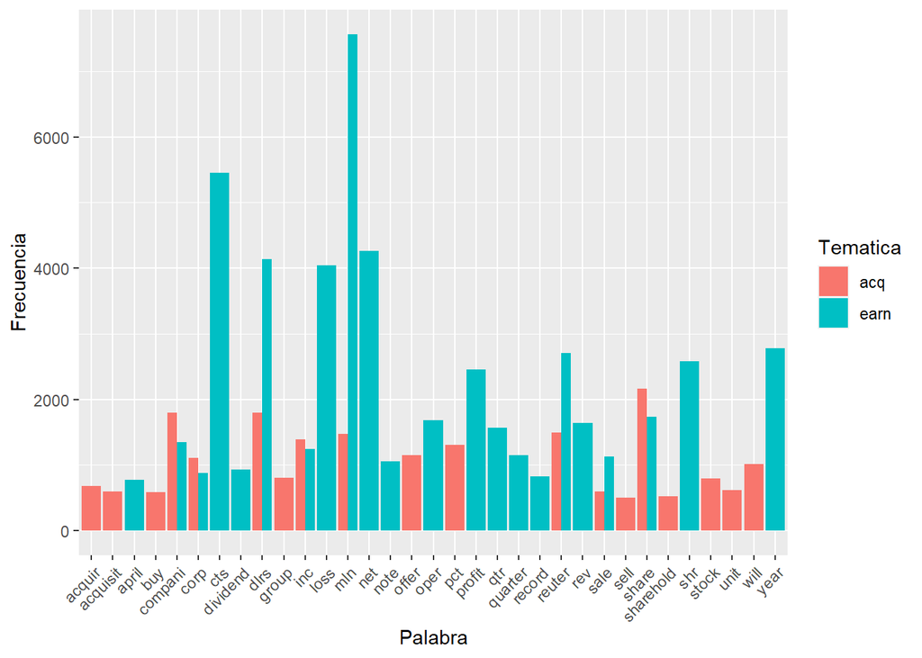

```r
colnames(fdata)<-c("Palabra", "Frecuencia", "Tematica")

# Gráfico de barras con las palabras más frecuentes
library(ggplot2)

ggplot(subset(fdata, Frecuencia>500),aes(Palabra,Frecuencia,fill=Tematica))+geom_bar(stat="identity",position=position_dodge())+theme(axis.text.x=element_text(angle=45, hjust=1))
```

## 8.2 Construcción de una nube de palabras

Podemos construir una nube de palabras para la matriz de términos con ambas temáticas.

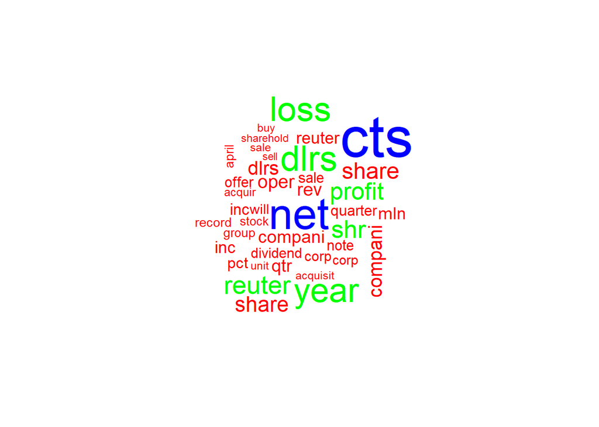

```r
# Cargamos la librería wordcloud
require(wordcloud)
# Construimos la nube de palabras o términos, para ello primero seleccionamos los que tienen una frecuencia superior a 500
sfdata<-subset(fdata, Frecuencia>500)
wordcloud(sfdata$Palabra, fdata$Frecuencia,min.freq=500,random.color=FALSE, colors=rainbow(3))
```